# The status of academic research on salmon farming: a living evidence map

# Results

## Review process

The review process is outlined in the flow diagram in Figure 1. Across the 21 databases searched, a total of 169,373 search results was obtained. Following deduplication, 79,554 unique candidate records remained. Title and abstract repair and enrichment supplemented 6,046 records, whilst a sweep for retractions identified 27 records that were excluded from further analysis.

Following screening of titles and abstracts, 27,726 were included in the map, and passed on to annotation. Species annotations were obtained for all 27,726 records, geography for 9,986 records, and topic classifications for 27,412 records.

[figure not shown]

*Figure 1.* *Flow of records through database searching, deduplication, record repair and enrichment, retraction screening, title-and-abstract screening, annotation and inclusion in the Living Evidence Map.*

### Screening validation and reviewer consistency

Across the saved human–model validation history, 21,950 substantive screening comparisons were available. The cumulative raw agreement was 96.79% and cumulative Cohen’s kappa was 0.922.

**Model validation history**

| Date | Records | Substantive comparisons | Raw agreement | Cohen’s κ |
| --- | --- | --- | --- | --- |
| 26-09-2026 | 22,198 | 21,950 | 96.8% | 0.922 |
| *Cumulative* | 22,198 | 21,950 | 96.8% | 0.922 |

Database provenance was retained through deduplication, allowing the contribution and overlap of the 21 bibliographic sources to be compared for the deduplicated corpus and the definitive final included corpus. Figure 2 shows records contributed uniquely by each database, while Figure 3 shows only multi-database overlaps.

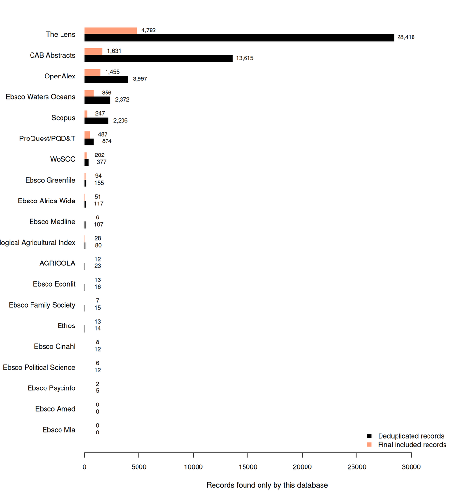

*Figure 2.* *Unique contribution of each bibliographic database. Records are counted as unique when they were retrieved from that database and no other searched database. Black bars show unique records in the deduplicated corpus; salmon-pink bars show the subset retained in the definitive final included corpus.*

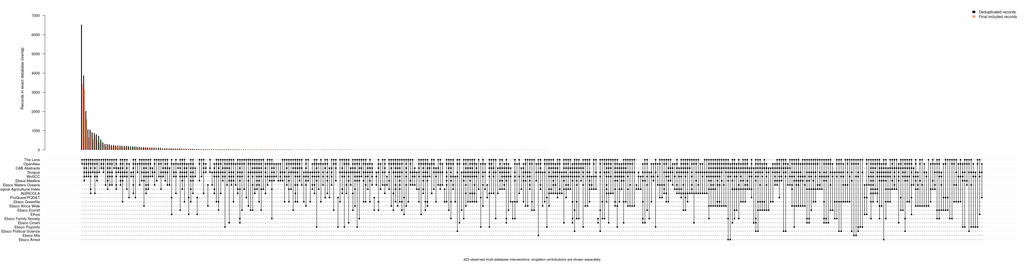

*Figure 3.* *Overlap among bibliographic databases. Only records retrieved from two or more databases are shown; single-database records are presented in Figure 2. Black bars show exact database intersections in the deduplicated corpus and salmon-pink bars show the corresponding records retained in the definitive final included corpus. The matrix indicates the databases represented in each intersection.*

## Publication year

The three largest focal species categories were Rainbow trout (12,186 records; 44.0%), Atlantic salmon (9,910; 35.7%) and Unspecified species (5,301; 19.1%). Species categories are not mutually exclusive because individual records can refer to more than one eligible farmed species.

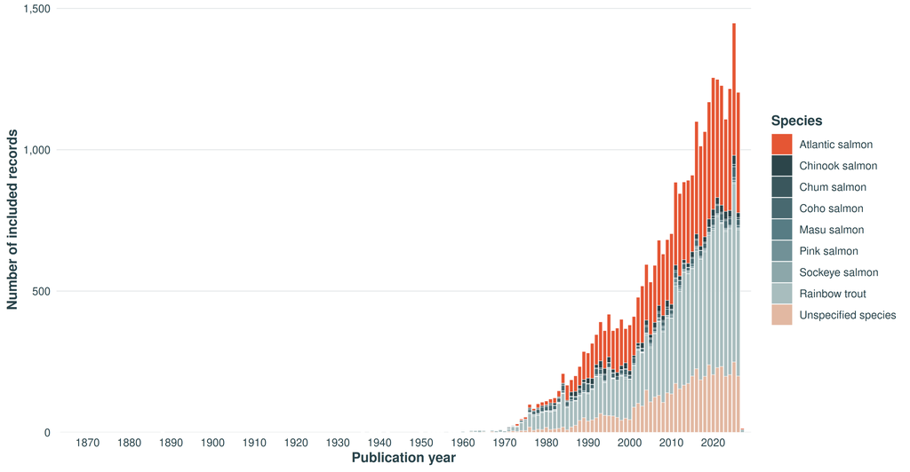

*Figure 4.* *Records by publication year and focal farmed species.*

The thematic composition of the literature also expanded through time. The largest high-level topic was Production, followed by Environment. Because records can receive more than one high-level topic, annual stacked totals represent topic-record assignments rather than mutually exclusive studies.

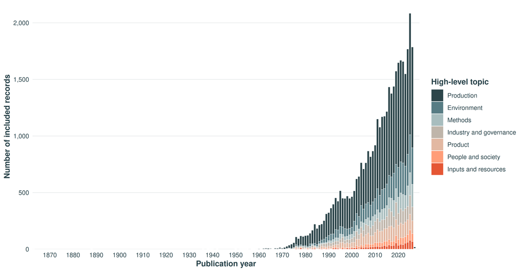

*Figure 5.* *Topic-assignment frequency for high-level topics by publication year.*

## Geography

A substantive study country could be resolved for 9,986 records (36.0%), while 17,740 included records (64.0%) did not contain sufficient evidence for a defensible country-level assignment. Among records with assigned geography (Figure 6), the largest country evidence bases were Norway (2,117 records), Canada (1,319), United Kingdom (1,172), Chile (1,159), United States (831), Turkey (554). Countries demonstrated strong species-specificity, as expected (Figure 7), with the major Atlantic salmon producing countries contributing most to the evidence base, and a large number of other countries contributing collectively to rainbow trout research (e.g. Turkey). Records may be assigned to more than one country where the substantive study spans multiple countries.

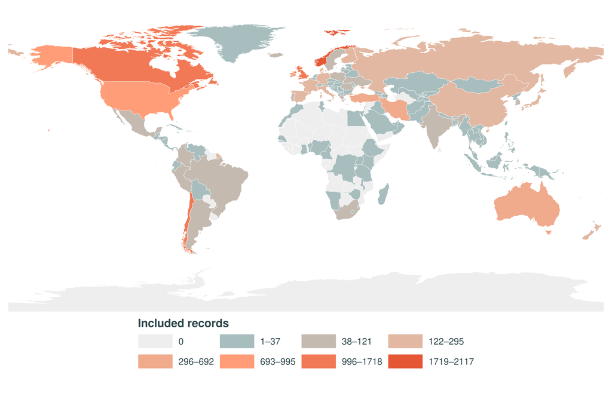

*Figure 6.* *Global distribution of included records by substantive study country.*

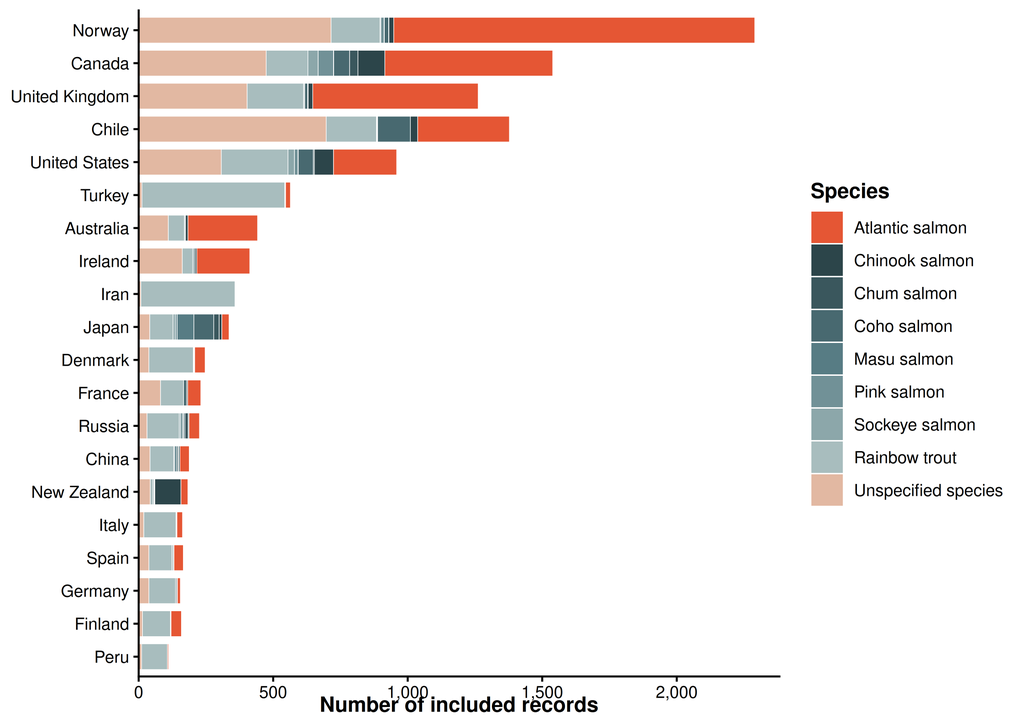

*Figure 7.* *Records per country for the 20 most frequently represented study countries, by focal farmed species.*

## Topics

At least one topic was assigned to 27,412 of the 27,726 included records; 314 records (1.1%) remained uncoded for topic. Across coded records, the final ontology contained 77,550 distinct record-topic assignments.

The evidence base was strongly oriented towards Production, represented in 21,291 records (76.8%). Environment was the second-largest theme (5,987; 21.6%), followed by Product (3,207; 11.6%), Industry and governance (3,133; 11.3%) and Methods (3,034; 10.9%). People and society (1,152; 4.2%) and Inputs and resources (950; 3.4%) were substantially smaller. Theme percentages are not mutually exclusive because a record can be assigned to more than one theme.

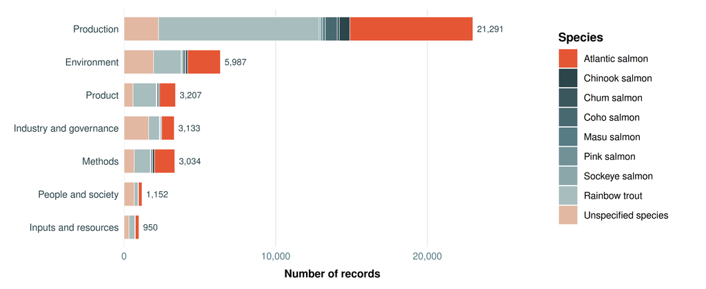

*Figure 8.* *High-level topic frequency by focal farmed species. Numbers at bar ends are unique records assigned to each high-level theme; stacked species segments may sum above the unique-record total for multi-species records.*

### Production

Production accounted for 21,291 records (76.8% of the full evidence map). Its leading Level 2 categories were Fish performance and biology (10,952 records; 51.4%), Fish health (9,424 records; 44.3%), and Feed and nutrition (6,701 records; 31.5%). Among these, the leading Level 3 topics were Fish performance and biology > Physiology, metabolism and biological responses (7,477 records; 35.1%), Fish performance and biology > Growth and development (4,839 records; 22.7%), Feed and nutrition > Alternative feed ingredients (2,532 records; 11.9%), Feed and nutrition > Feed additives and supplements (2,515 records; 11.8%), and Fish health > Other diseases - Prevention and treatment (2,478 records; 11.6%).

[figure not shown]

*Figure 9.* *Topic-assignment frequency within the Production theme.*

### Environment

Environment accounted for 5,987 records (21.6% of the full evidence map). Its leading Level 2 categories were Environmental stressors (1,781 records; 29.7%), Waste and emissions (1,697 records; 28.3%), Wild populations and ecosystems (1,582 records; 26.4%), Environmental management (1,305 records; 21.8%), and Physical environment (1,214 records; 20.3%). Among these, the leading Level 3 topics were Environmental stressors > Water and ocean conditions (1,545 records; 25.8%), Waste and emissions > Nutrients and organic waste (1,282 records; 21.4%), Wild populations and ecosystems > Biodiversity and ecosystem effects (1,216 records; 20.3%), and Environmental management > Monitoring and assessment (977 records; 16.3%).

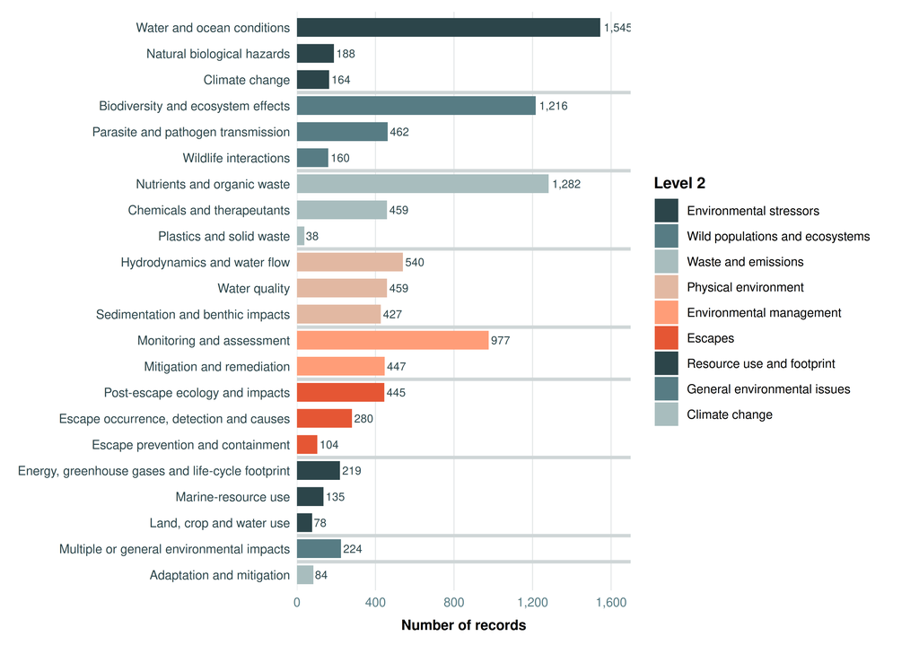

*Figure 10.* *Topic-assignment frequency within the Environment theme.*

### Methods

Methods accounted for 3,034 records (10.9% of the full evidence map). Its leading Level 2 categories were Methodological research (3,034 records; 100.0%). Among these, the leading Level 3 topics were Methodological research > Diagnostic and laboratory methods (1,644 records; 54.2%), Methodological research > Statistical and modelling methods (806 records; 26.6%), Methodological research > Monitoring and sampling methods (570 records; 18.8%), and Methodological research > Sensors, imaging and measurement methods (469 records; 15.5%).

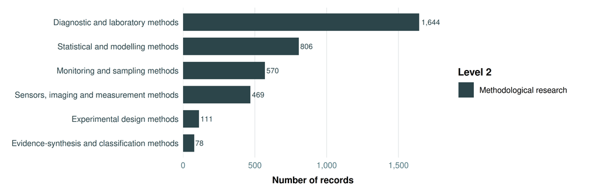

*Figure 11.* *Topic-assignment frequency within the Methods theme.*

### Industry and governance

Industry and governance accounted for 3,133 records (11.3% of the full evidence map). Its leading Level 2 categories were Governance and policy (1,290 records; 41.2%), Economics and performance (1,195 records; 38.1%), Sector development (838 records; 26.7%), and Markets, trade and value chains (827 records; 26.4%). Among these, the leading Level 3 topics were Governance and policy > Policy and regulation (1,094 records; 34.9%), Economics and performance > Costs and profitability (709 records; 22.6%), Sector development > History and regional development (595 records; 19.0%), Economics and performance > Economic risk, valuation and impact (547 records; 17.5%), and Markets, trade and value chains > Supply, demand and prices (540 records; 17.2%).

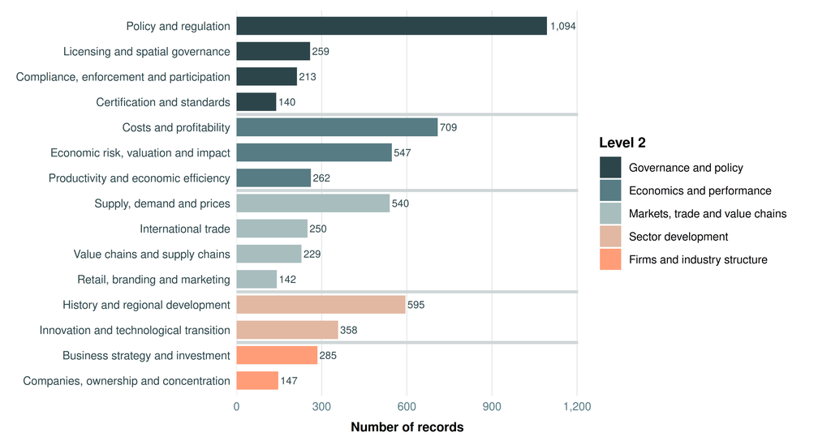

*Figure 12.* *Topic-assignment frequency within the Industry and governance theme.*

### Product

Product accounted for 3,207 records (11.6% of the full evidence map). Its leading Level 2 categories were Composition and nutritional value (1,645 records; 51.3%), Fillet and carcass quality (1,131 records; 35.3%), Food safety (576 records; 18.0%), Processing and preservation (463 records; 14.4%), and Sensory quality (437 records; 13.6%). Among these, the leading Level 3 topics were Composition and nutritional value > Nutritional composition (1,105 records; 34.5%), Fillet and carcass quality > Physical and visual quality (838 records; 26.1%), and Composition and nutritional value > Contaminants and residues (606 records; 18.9%).

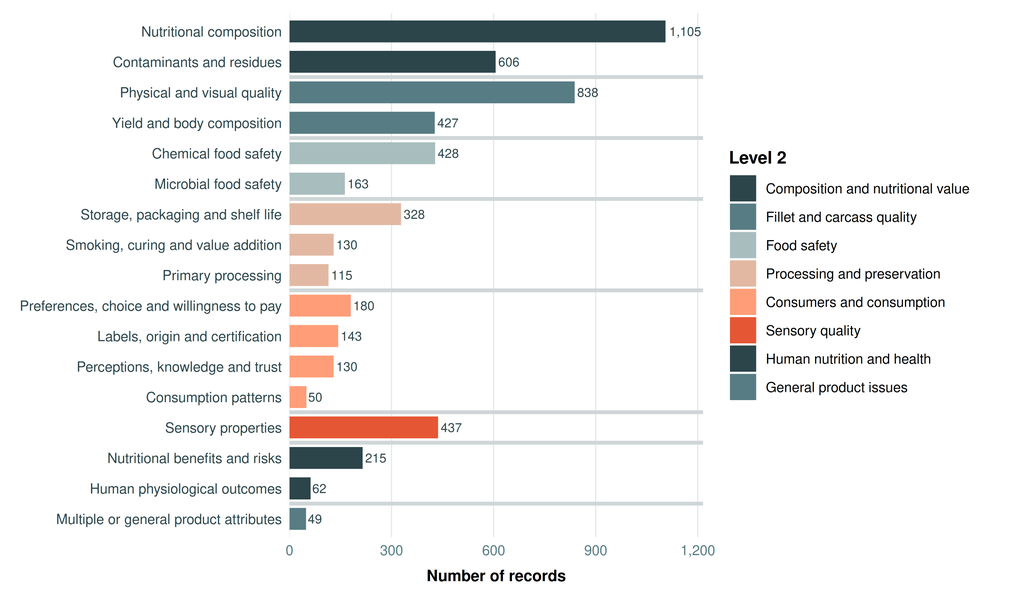

*Figure 13.* *Topic-assignment frequency within the Product theme.*

### People and society

People and society accounted for 1,152 records (4.2% of the full evidence map). Its leading Level 2 categories were Communities and livelihoods (430 records; 37.3%), Culture and knowledge (317 records; 27.5%), and Public health (308 records; 26.7%). Among these, the leading Level 3 topics were Public health > Antimicrobial resistance and One Health (295 records; 25.6%), Communities and livelihoods > Conflict and social licence (271 records; 23.5%), and Culture and knowledge > Public discourse and representation (246 records; 21.4%).

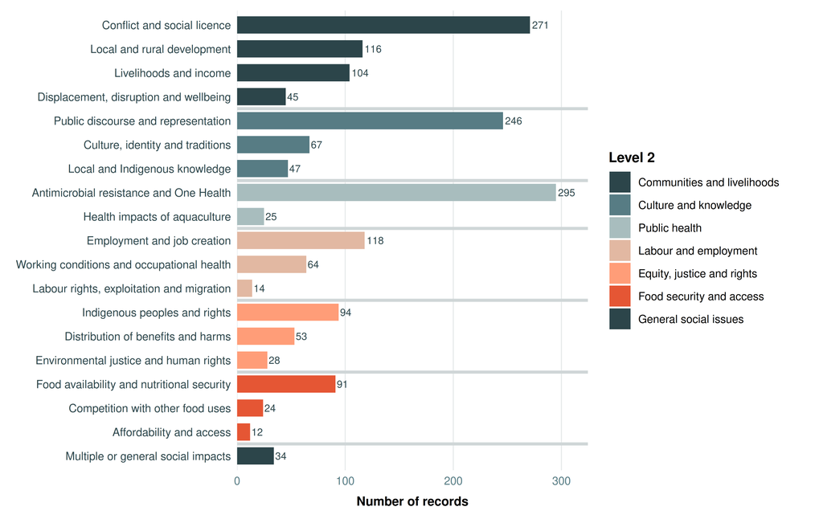

*Figure 14.* *Topic-assignment frequency within the People and society theme.*

### Inputs and resources

Inputs and resources accounted for 950 records (3.4% of the full evidence map). Its leading Level 2 categories were Circularity (714 records; 75.2%), Feed-resource supply (195 records; 20.5%), and Farm inputs (121 records; 12.7%). Among these, the leading Level 3 topics were Circularity > By-products and waste as inputs (651 records; 68.5%), Circularity > Resource efficiency (119 records; 12.5%), Feed-resource supply > Novel feed resources (104 records; 10.9%), Circularity > Nutrient recovery (93 records; 9.8%), and Feed-resource supply > Marine feed resources (86 records; 9.1%).

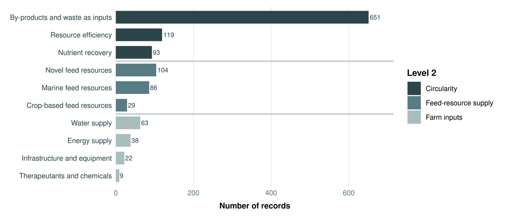

*Figure 15.* *Topic-assignment frequency within the Inputs and resources theme.*

## Comparison with secondary research

We compare these results with a recent umbrella review of 37 systematic reviews across salmon aquaculture (Haddaway et al. 2026). This comparison shows substantial differences between the distribution of primary research and systematic-review coverage. Sea lice control and treatment occurs in 850 mapped records (3.1%), compared with 8 of 37 systematic reviews (21.6%) in the umbrella-review dataset. By contrast, several of the largest areas in the mapped literature have comparatively little systematic-review coverage, including Physiology, metabolism and biological responses (27.0% of mapped records), Growth and development (17.5%), and major disease, environmental and methodological topics.

Social research was particularly weakly represented in the systematic-review literature. In the final canonical map, Antimicrobial resistance and One Health accounts for 1.1% of records, Conflict and social licence for 1.0%, and Public discourse and representation for 0.9%; the umbrella review includes one review on antimicrobial resistance/One Health and none in most of the other social categories. Overall, the comparison continues to indicate that the systematic-review evidence covers a narrower subset of the topics represented across the mapped literature, with particularly strong representation of sea lice and limited coverage of several major physiological, environmental, methodological, governance and social research areas.

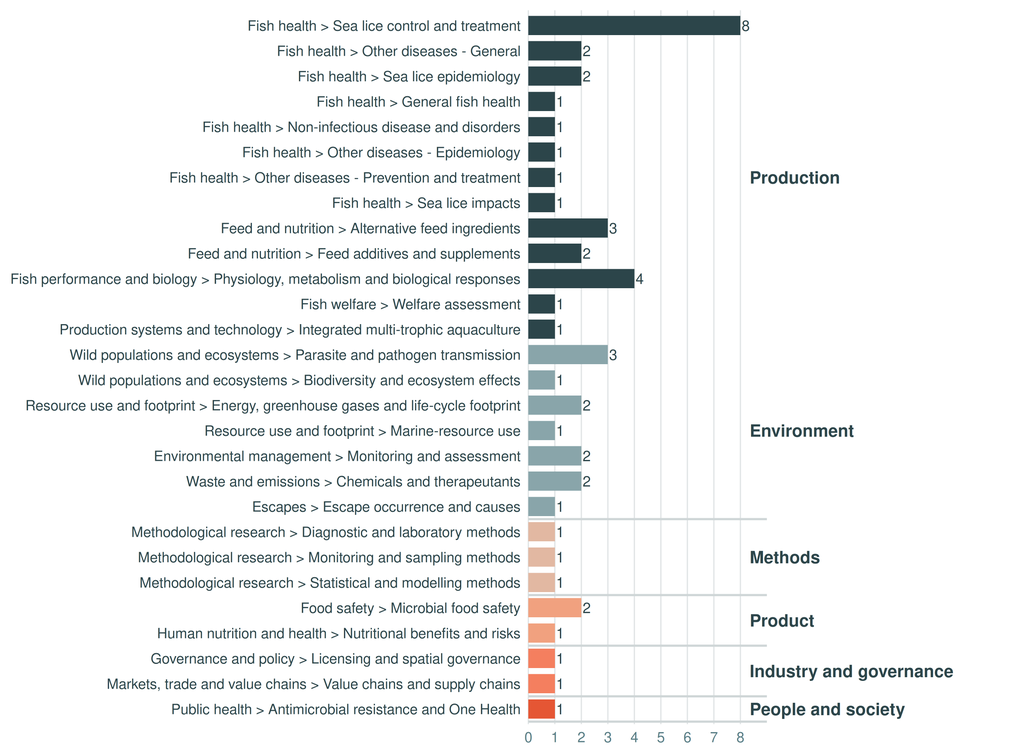

*Figure 16.* *Topic-assignment frequency among the 37 systematic reviews included in the umbrella review (Haddaway et al. 2026).*

# References

Haddaway, Neal, María D. López Rodríguez, Heather Cooley, et al. 2026. “What Evidence Exists on Salmon Farming? An Overview of Reviews.” *Environmental Evidence*. https://doi.org/10.1186/s13750-026-00391-y.